# 第10回 ラグランジュの未定乗数法

経済学基礎数学II

第10回

ラグランジュの未定乗数法

縛りがあるときの最大化

経済学基礎数学II

第10回 — Topic01

限界代替率

標高を変えずに歩く

## 第10回の道のり

1

限界代替率

演習 1-1 限界代替率の値と読み

2

代入法

演習 2-1 代入法の答え

3

ラグランジュ

演習 3-1 $4$ STEP を通す

4

例題と罰金

演習 4-1 割って $\lambda$ を消す

いまココ — 前回の等高線の傾きを、買い物の交換の割合に移す

## 前回の振り返り

前回のポイント — 全微分と等高線の傾き

Q: 標高や給料を変えずに動く向きを、どう出したか

- **全微分**: 斜めの $1$ 歩を、$x$ 方向の分と $y$ 方向の分に分けて足した
- **等高線の傾き**: $dz = 0$ とおいて、  
  $2$ つの偏微分の比にマイナスを付けた
- **交換の比率**: 給料を変えずに、  
  時給とシフトをどう交換できるかを出した

この等高線の傾きを、今日は買い物の話に使う

## 等高線の傾きの復習

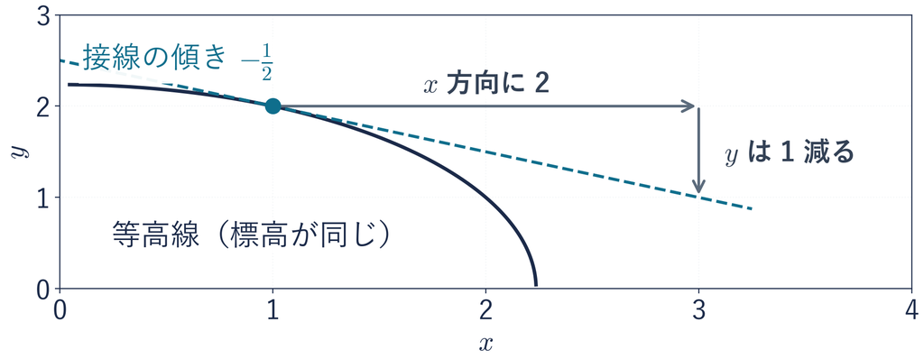

丘 $f(x, y) = 10 - x^2 - y^2$ の点 $(1, 2)$ で、等高線の傾きは $-\frac{1}{2}$  
標高がほとんど変わらないのは、接線に沿ってほんの少し進むとき

## このトピックで学ぶこと

- **いまの道具**：等高線の傾きで、  
  給料を変えずに時給とシフトをどう交換できるかが出せた
- **足りない所**：友だちに  
  「りんごを少しあげるから、みかんをちょうだい」と言われた  
  傾きは出せる。足りないのは  
  「りんご $1$ 個あたり、みかん何個まで」と読む決まりと名前
- **知りたいこと**：いまの買い方で、りんご $1$ 個とみかん何個が釣り合うか
- **新しい道具**：限界代替率（げんかいだいたいりつ）  
  限界＝もう少しだけ増やすとき、代替＝取り替える、率＝割合
- **つまり**：満足を変えずに取り替えられる割合  
  （りんご $1$ 個で、みかん何個まで）

まず満足の表と図で割合を数え、そのあと式で出す

## 山の話と経済の話の対応

標高を満足に、$x$ と $y$ をりんごの個数とみかんの個数に置き換える

| 山の話 | 経済の話 |
| --- | --- |
| $x$ 方向・$y$ 方向 | りんご $x$ 個・みかん $y$ 個 |
| 標高 $f(x,y)$ | 満足 $u(x,y)$（**効用**） |
| 等高線 | **無差別曲線**：満足が同じになる買い方をつないだ線 |
| 等高線の傾き | 満足を変えずに、りんごとみかんを交換する割合 |

「無差別」は、線の上のどの買い方を選んでも満足に差が無い、という意味

## 前に出てきた $u = 6$ の表

満足 $u(x,y) = xy$ が $u = 6$ になる、りんご $x$ 個とみかん $y$ 個の買い方

| りんご $x$ | みかん $y$ |
| --- | --- |
| $1$ | $6$ |
| $2$ | $3$ |
| $3$ | $2$ |
| $6$ | $1$ |

「交換してよい割合が、場所によって変わる」と言ってあった。  
今日はその割合を数で出す

## 表の上の取り替え

[figure not shown]

同じ「りんご $+1$」でも、手放すみかんは $3$ 個 → $1$ 個と、途中で割合が変わる

だから、いる点での**ほんの少しの割合**を測る。これが接線の傾き

## 無差別曲線の傾き

$u(x,y) = xy$ の無差別曲線の傾きを、前回の等高線の傾きで出す

$\frac{\partial u}{\partial x}$

$= y$

$y$ を定数と思って $x$ で偏微分

$\frac{\partial u}{\partial y}$

$= x$

$x$ を定数と思って $y$ で偏微分

$\frac{dy}{dx}$

$= -\frac{\partial u/\partial x}{\partial u/\partial y}$

前回の等高線の傾き

$= -\dfrac{y}{x}$

$2$ つを入れる

点 $(2,3)$ なら $-\frac{3}{2} = -1.5$ マイナスは  
「りんごを増やすなら、みかんは減らす」向きの印

## 限界代替率の定義

満足を変えずにいるなら、りんご $1$ 個はみかん何個ぶんか。それを測る数

定義 — 限界代替率

$$\text{限界代替率} = \frac{\partial u/\partial x}{\partial u/\partial y}$$

- **意味**：りんごを $1$ 個もらうかわりに、  
  みかんをおよそ何個まで手放してよいか（りんご $1$ 個あたりの割合）
- **絶対値**：無差別曲線の傾きからマイナスを外す。知りたいのは手放す**量**
- **今回は**：$u = xy$ なら $\frac{y}{x}$. 点 $(2, 3)$ で $1.5$

## 「1 個」はほんの少しの言いかえ

点 $(2, 3)$ の限界代替率 $1.5$ は  
表の取り替え（前は $3$ 個・後は $1$ 個）の間に入る割合

| 点 $(2, 3)$ から、りんごを | $1.5$ の割合で見積もる | 満足 $6$ のまま、 実際に手放せる |
| --- | --- | --- |
| $0.1$ 個増やす | みかん $0.15$ 個 | みかん 約 $0.14$ 個 |
| $1$ 個増やす | みかん $1.5$ 個 | みかん $1$ 個（表の $(3,2)$） |

少しなら見積もりどおり。だから「**およそ** $1.5$ 個まで」と読む  
友だちの話：りんご $0.1$ 個なら、みかんはおよそ $0.15$ 個まで渡してよい

## 限界効用の比

前に出てきた**限界効用**：もう $1$ 個増やしたときの、満足のおよその増え方

りんごの限界効用

$\dfrac{\partial u}{\partial x\vphantom{y}}(2, 3) = 3$

りんごをもう $1$ 個で、  
満足がおよそ $3$ 増える

みかんの限界効用

$\dfrac{\partial u}{\partial y}(2, 3) = 2$

みかんをもう $1$ 個で、  
満足がおよそ $2$ 増える

りんご $1$ 個の値打ちは、みかん $\frac{3}{2} = 1.5$ 個ぶん  
みかん $1.5$ 個なら、満足はおよそ $2 \times 1.5 = 3$ 増えて、りんご $1$ 個と同じ  
だから限界代替率は、上がりんご、下がみかん

## ◼ 限界代替率の求め方 STEP $4$ つ

$u = xy$ でやったことを、この順に並べる

1. **偏微分を $2$ つ作る**（$x$ で $1$ 回、$y$ で $1$ 回）
2. **上を $x$ の偏微分、下を $y$ の偏微分にして分数にする**
3. **頭にマイナスを付ける**（ここまでが傾き $\frac{dy}{dx}$）
4. **絶対値をとり、「りんご $1$ 個あたり、みかん □ 個の割合」と読む**

STEP 1〜3 は前回の等高線の傾きと同じ。約分は STEP 2 で  
点は、傾きを聞かれたら STEP 3 で、限界代替率なら STEP 4 で入れる

## 例題 $u = x^4 y$ の限界代替率

満足 $u(x, y) = x^4 y$ の限界代替率を求め、点 $(2, 3)$ での値を読む

STEP 1

$\frac{\partial u}{\partial x} = 4x^3 y$, $\frac{\partial u}{\partial y} = x^4$

相手を定数と思って偏微分

STEP 2

$\frac{4x^3 y}{x^4} = \frac{4y}{x}$

上が $x$ の偏微分。$x^3 \div x^4$ を約分

STEP 3

$\frac{dy}{dx} = -\frac{4y}{x}$

頭にマイナス。ここまでが傾き

STEP 4

$\frac{4y}{x} = \frac{4 \times 3}{2} = 6$

絶対値をとり、点 $(2, 3)$ を入れる

こたえ $6$ りんご $1$ 個あたり、みかん $6$ 個の割合

## 場所ごとの限界代替率

$u = xy$ の $u = 6$ の線の $4$ 点で、STEP 4 まで通す

| 立っている場所 | 傾き $\frac{dy}{dx}$ | 限界代替率 | りんご $1$ 個 あたりの割合 |
| --- | --- | --- | --- |
| $(1,\ 6)$ | $-6$ | $6$ | みかん $6$ 個 |
| $(2,\ 3)$ | $-1.5$ | $1.5$ | みかん $1.5$ 個 |
| $(3,\ 2)$ | $-\frac{2}{3}$ | 約 $0.67$ | みかん $0.67$ 個 |
| $(6,\ 1)$ | $-\frac{1}{6}$ | 約 $0.17$ | みかん $0.17$ 個 |

右へ行くほど、値がどんどん小さくなっている

## 寝ていく接線

[figure not shown]

同じ曲線の上でも、右へ行くほど接線が寝ていく

## 左端と右端の割合

[figure not shown]

左端はりんご、右端はみかんが足りない。足りないほうが欲しくなる

## 限界代替率の逓減

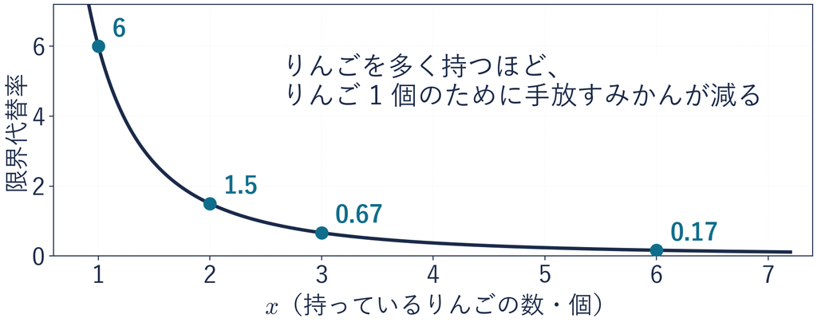

**逓減**（ていげん）：だんだん減ること。限界生産力の逓減と同じ形  
だから、片方に偏るより、両方を少しずつ買いたくなる

## 演習 1-1 限界代替率の値と読み

演習 1-1

限界代替率を式で出し、点での値を言葉にする

- **復習 A** $u(x, y) = x^5 y^2$ を、$x$ と $y$ でそれぞれ偏微分
1. $u = x y^3$, 点 $(1, 9)$
2. $u = xy$, 点 $(8, 2)$. 傾き $\frac{dy}{dx}$ の値と限界代替率の値の**両方**
3. $u = x^2 y^2$, 点 $(2, 5)$

値は「りんご $1$ 個あたり、みかん □ 個の割合」と言葉にする

⏸ PAUSE 動画を止めて、ノートに解く。問 $1$・$2$ が解けたら再生に戻る  
問 $3$ と復習 A は、そのあと解いて配った答えで確かめる

## 演習 1-1 の答え — 問 $1$

**問 $1$** $u = x y^3$ 点 $(1, 9)$

STEP 1

$\frac{\partial u}{\partial x} = y^3$, $\frac{\partial u}{\partial y} = 3xy^2$

相手を定数と思って偏微分

STEP 2

$\frac{y^3}{3xy^2} = \frac{y}{3x}$

上が $x$ の偏微分。$y^3 \div y^2$ を約分

STEP 3

$\frac{dy}{dx} = -\frac{y}{3x}$

頭にマイナス。ここまでが傾き

STEP 4

$\frac{y}{3x} = \frac{9}{3 \times 1} = 3$

絶対値をとり、点 $(1, 9)$ を入れる

こたえ $3$ りんご $1$ 個あたり、みかん $3$ 個の割合  
「およそ $3$ 個まで手放してよい」と読む

## 演習 1-1 の答え — 問 $2$

**問 $2$** $u = xy$ 点 $(8, 2)$. 傾きと限界代替率の両方

STEP 1

$\frac{\partial u}{\partial x} = y$, $\frac{\partial u}{\partial y} = x$

相手を定数と思って偏微分

STEP 2

$\frac{y}{x}$

上が $x$ の偏微分

STEP 3

$\frac{dy}{dx} = -\frac{y}{x} = -\frac{2}{8} = -\frac{1}{4}$

傾きを聞かれたら、  
ここで点を入れて答える

STEP 4

$\frac{y}{x} = \frac{2}{8} = \frac{1}{4} = 0.25$

限界代替率は絶対値

こたえ 傾き $-\frac{1}{4}$ 限界代替率 $\frac{1}{4}$  
りんご $1$ 個あたり、みかん $0.25$ 個の割合（$1$ 個に満たない）

## まとめ

- 限界代替率：満足を変えずに、りんご $1$ 個あたり、  
  みかんを何個まで手放してよいかの割合。  
  無差別曲線の傾きの絶対値
- 求め方は STEP $4$ つ  
  （偏微分 $2$ つ → 上が $x$ の分数 → マイナスで傾き → 絶対値で読む）
- 限界効用の比なので、上がりんご、下がみかん
- 右へ行くほど小さくなる。これが**逓減**

交換の割合は、数で言えるようになった  
まだ答えていない問い：お金に限りがあるとき、  
どの買い方がいちばん良いか。これを次のトピックで見る

経済学基礎数学II

第10回 — Topic02

代入法

決められた道の上を歩く

## 第10回の道のり

1

限界代替率

演習 1-1 限界代替率の値と読み

2

代入法

演習 2-1 代入法の答え

3

ラグランジュ

演習 3-1 $4$ STEP を通す

4

例題と罰金

演習 4-1 割って $\lambda$ を消す

いまココ — お金に限りがある中で、いちばん良い買い方を探す

## このトピックで学ぶこと

- **いまの道具**：限界代替率で、りんごとみかんを交換する割合が言える  
  前の回の頂点探しは、$x$ も $y$ も好きに動かせた
- **足りない所**：交換の割合が言えても、  
  持っているお金で何個ずつ買うかは決まらない  
  満足は買うほど増える。縛りが無ければ「いくらでも買う」
- **知りたいこと**：お金の縛りの中で、満足がいちばん大きい買い方
- **新しい道具**：予算制約と代入法（縛りを使って文字を $1$ つ減らす）

**いちばん良いもの**は、たいてい**できる範囲で**いちばん良いもの

## この回で使う例

りんご $x$ 個（$1$ 個 $2$ 円）・みかん $y$ 個（$1$ 個 $3$ 円）・持っているお金は $12$ 円

- **満足**：$u(x,y) = xy$ りんごもみかんも、増えるほど大きくなる
- **縛り**（しばり）：動ける範囲を決めている式。数学では**制約**と呼ぶ
- **使うお金**：りんごに $2x$ 円、みかんに $3y$ 円。合わせて $2x + 3y$ 円

**約束**：りんごもみかんも、$1.5$ 個のような半端な数でも売ってくれる  
「縛り」と「制約」は同じもの。予算制約のような熟語では「制約」を使う

## 予算制約と買える範囲

[figure not shown]

**予算制約**：使うお金は、持っているお金まで $2x + 3y \leq 12$

**予算線**：三角形の境目 $2x + 3y = 12$ お金をちょうど使い切る買い方

## 余りの買い足し

[figure not shown]

線より内側の点 $(1.5, 2)$ で止まると、お金が $3$ 円余る

## 答えが予算線の上にある理由

- **約束**：満足 $u = xy$ はりんごとみかんの個数だけで  
  決まる。余ったお金は入らない
- りんごもみかんも、増えるほど満足は大きい
- 三角形の内側のどの点でも、お金が余る。  
  余りで少しずつ買い足せば、満足は必ず上がる

だから答えは**必ず予算線の上**。この先は $2x + 3y = 12$ で探す

ただし線の上でも、場所で満足は違う  
$(1.5, 3)$ は $4.5$. いちばん高い所を次に探す

## デモ：満足の山を、幕で切る

数の話

満足の山＝床の点 $(x, y)$ の上に、満足 $u = xy$ を高さとして立てた面

- **何を見るか**：幕が山を切った線（幕の切り口）で、満足がいちばん高くなる点
- **図の意味**：紺は予算線、床の薄い三角形は買える範囲。  
  橙は幕＝予算線の上に立てた縦の壁で、線の上の買い方だけを残す
- **操作**：タブで場面を替える。ドラッグか「回す」で向きを変える

ミッション 幕の上で、満足がいちばん高い点探し

※ 次のスライドへ進むときは、デモの枠の外を一度クリックしてから ← → キーを押す

[interactive chart not shown]

## 横から見た幕の切り口

[figure not shown]

予算線の上では、$x$ を決めると $y$ も決まる（$x = 3$ なら $y = 2$）

だから満足は $x$ だけで決まる $1$ 変数の山。てっぺんで傾きは $0$

## ◼ 代入法の求め方 STEP $4$ つ

縛りで文字を $1$ つ減らし、$1$ 変数の山にする。頂上は春学期の「微分して $0$」  
答えは予算線の上なので、予算制約の $\leq$ を $=$ に替えてから解く

1. **縛り（$=$ の式）を $y = \cdots$ の形に解く**
2. **満足の式に入れて、$x$ だけの式にする**
3. **微分して $= 0$ とおく**
4. **$x$ から $y$ と、そのときの満足を出す**

$x$ だけの式（STEP 2）が、幕の切り口の山  
そのてっぺんを探すのが STEP 3

## 例題 $u = xy$, $2x + 3y = 12$ の代入法

STEP 1

$3y = 12 - 2x$

予算線を $y$ で解く

$\Rightarrow\; y = 4 - \frac{2}{3}x$

$2x$ も $3$ で割る

STEP 2

$u = x\left(4 - \frac{2}{3}x\right) = 4x - \frac{2}{3}x^2$

幕の切り口の式

STEP 3

$\frac{du}{dx} = 4 - \frac{4}{3}x = 0 \;\Rightarrow\; x = 3$

微分して $0$. $\frac{4}{3}x = 4$ を解く

STEP 4

$y = 4 - 2 = 2$, $u = 3 \times 2 = 6$

$y$ と満足を出す

## 演習 2-1 代入法の答え

演習 2-1

縛りを代入して、$1$ 変数の最大にする

問 $1$・$2$ とも、$(x, y)$ と、そのときの $u$ の値を答える

1. $u = xy$ を $x + 5y = 30$ のもとで最大に
2. $u = xy$ を $2x + 3y = 36$ のもとで最大に

復習 B $f(x) = 10x - x^2$ で $f'(x) = 0$ となる $x$ と $f$ の値  
（STEP 3 だけの練習。問 $1$・$2$ でつまずいたら先にこれを）

⏸ PAUSE 動画を止めて、ノートに解く。問 $1$・$2$ が解けたら再生に戻る  
復習 B は、配った答えで確かめる

## 演習 2-1 の答え — 問 $1$

**問 $1$** $u = xy$ を $x + 5y = 30$ のもとで最大に

STEP 1

$5y = 30 - x \;\Rightarrow\; y = 6 - \frac{x}{5}$

縛りを $y$ で解く

STEP 2

$u = x\left(6 - \frac{x}{5}\right) = 6x - \frac{x^2}{5}$

$u = xy$ に入れる

STEP 3

$\frac{du}{dx} = 6 - \frac{2x}{5} = 0 \;\Rightarrow\; x = 15$

微分して $0$ とおく

STEP 4

$y = 6 - 3 = 3$, $u = 15 \times 3 = 45$

$y$ と満足を出す

こたえ $(15, 3)$ $u = 45$  
$15 + 5 \times 3 = 30$ なので、縛りもちゃんと守れている

## 演習 2-1 の答え — 問 $2$

**問 $2$** $u = xy$ を $2x + 3y = 36$ のもとで最大に

STEP 1

$3y = 36 - 2x$

縛りを $y$ で解く

$\Rightarrow\; y = 12 - \frac{2x}{3}$

$2x$ も $3$ で割る

STEP 2

$u = x\left(12 - \frac{2x}{3}\right) = 12x - \frac{2x^2}{3}$

$u = xy$ に入れる

STEP 3

$\frac{du}{dx} = 12 - \frac{4x}{3} = 0 \;\Rightarrow\; x = 9$

微分して $0$ とおく

STEP 4

$y = 12 - 6 = 6$, $u = 9 \times 6 = 54$

$y$ と満足を出す

こたえ $(9, 6)$ $u = 54$  
$2 \times 9 + 3 \times 6 = 36$. 「$36$ 円まで」と言われても、答えは使い切る線の上

## 代入すると汚くなる例

満足が $u = x^{1/2}y^{1/2}$（$x^{1/2} = \sqrt{x}$）なら、同じ予算線で代入してみる  
買うほど増え方がゆるやかな形。ここでは解かず、手順の重さだけ見る

$u = x^{1/2}\left(4 - \frac{2}{3}x\right)^{1/2}$

縛りの $y$ を入れただけ。まだ何も計算していない

- **積の微分**が要る：$x^{1/2}$ と、うしろの塊のかけ算になっている
- **合成の微分**も要る：うしろの塊は「中身の $1/2$ 乗」である
- **縛りが曲がっている**と（$x^2 + y^2 = 25$ など）、$y$ にルート（$\sqrt{\ }$）が出る

## まとめ

- 予算制約は $2x + 3y \leq 12$. 三角形の中なら、どこでも買える
- 余りがあれば買い足せて、満足が上がる。  
  だから答えは予算線の上（$=$）
- 代入法は STEP $4$ つ（$y$ で解く → 入れる → 微分して $0$ → $y$ と満足）
- $u = xy$, $2x + 3y = 12$ の答えは $(3, 2)$, $u = 6$. 幕のてっぺん

縛りの線の上で、いちばん良い買い方が出せるようになった  
まだ答えていない問い：代入が汚くなる形でも、  
いつも同じ手順で回る方法はあるか。これを次のトピックで見る

経済学基礎数学II

第10回 — Topic03

ラグランジュの未定乗数法

接するところに答えがある

## 第10回の道のり

1

限界代替率

演習 1-1 限界代替率の値と読み

2

代入法

演習 2-1 代入法の答え

3

ラグランジュ

演習 3-1 $4$ STEP を通す

4

例題と罰金

演習 4-1 割って $\lambda$ を消す

いまココ — この回の山場。答えのありかを、山の絵で見つける

## このトピックで学ぶこと

- **いまの道具**：代入法で、予算 $12$ 円（りんご $2$ 円・みかん $3$ 円）  
  のいちばん良い買い方 $(3, 2)$, $u = 6$ が出せた
- **足りない所**：満足が $u = x^{1/2}y^{1/2}$ だと、  
  代入した式 $u = x^{1/2}\left(\frac{12 - 2x}{3}\right)^{1/2}$ の微分に、積と合成が同時に要る
- **知りたいこと**：代入せずに、いつも同じ手順で答えが出る方法
- **新しい道具**：ラグランジュの未定乗数法（みていじょうすうほう）

答えのありかを山の絵で見つけ、それを式に書き直して、手順にする

## 水平の板とその切り口

トピック 2 は、縦の幕で満足の山を切り、代入して答えを出した  
今度は代入せずに、山を水平に切って、答えのありかを目で見る

- **水平の板**：満足の高さを $1$ つ決めて、  
  山を水平に切る板（青緑）
- **板の切り口**：満足がちょうどその高さになる  
  買い方の線。トピック 1 の**無差別曲線**
- **床に落とす**：切り口を真下の床に写すと、  
  予算線と同じ床の線

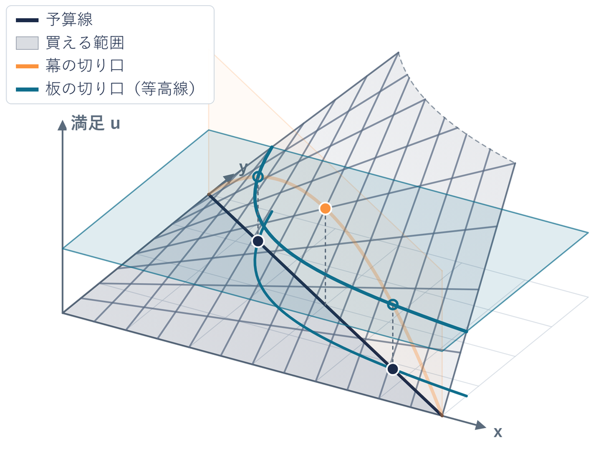

板の高さを $4$, $6$, $8$ と上げていくと、床の切り口と予算線の出会い方が変わる

## デモ：満足の山を、水平の板で切る

数の話

板の切り口 $xy = h$：満足がちょうど $h$ になる買い方の線（無差別曲線）

- **何を見るか**：床の切り口と予算線の出会い方。板を $4$ → $6$ → $8$ と上げると、  
  $2$ か所 → $1$ 点 → $0$ か所に変わる
- **図の意味**：青緑は板と、その切り口（床の濃い線）。  
  紺は予算線。薄い橙はトピック 2 の幕
- **操作**：③ 水平の板 → ④ 真上から → ⑤ 傾き の順にタブを押す。  
  板の高さはスライダか 4・6・8

ミッション 板を高さ $5$・$7$ にして、接する高さが $1$ つかを確認

※ 次のスライドへ進むときは、デモの枠の外を一度クリックしてから ← → キーを押す

[interactive chart not shown]

## 真上から見た $3$ 本の切り口

[figure not shown]

$2$ か所で横切るうちは、予算線に沿って進めば、もっと高い切り口に移れる  
**接した高さ $u = 6$ が、$12$ 円で届くいちばん上**。その接点が答え

## 接点での $2$ 本の傾き

[figure not shown]

限界代替率 $\frac{y}{x}$ と値段の比が、どちらも $\frac{2}{3}$. 取り替えても、もう得をしない

## 並べ替えで現れる $\lambda$

一般に、りんご $1$ 個 $p$ 円・みかん $1$ 個 $q$ 円・予算 $I$ 円とする  
接点で同じになる $2$ 本の傾きは、どちらもマイナス。  
マイナスを外した大きさで比べる

$\frac{\partial u/\partial x}{\partial u/\partial y} = \frac{p}{q}$

限界代替率（$u = xy$ なら $\frac{y}{x}$）と値段の比が等しい

$q\,\frac{\partial u}{\partial x} = p\,\frac{\partial u}{\partial y}$

両辺に $q$ と $\frac{\partial u}{\partial y}$ を掛け、分数をなくす

$\frac{1}{p}\frac{\partial u}{\partial x} = \frac{1}{q}\frac{\partial u}{\partial y}$

両辺を $pq$ で割る

$\lambda = \frac{1}{p}\frac{\partial u}{\partial x} = \frac{1}{q}\frac{\partial u}{\partial y}$

同じ値に名前 $\lambda$（ラムダ）

$\frac{\partial u}{\partial x} = \lambda p,\quad \frac{\partial u}{\partial y} = \lambda q$

$p$・$q$ を掛け戻す

## 接点 $(3, 2)$ での $\lambda$

接点 $(3, 2)$ で、$u = xy$, $p = 2$, $q = 3$ を入れてみる

| 見るもの | 限界効用 | $\lambda =$ 限界効用 ÷ 値段 |
| --- | --- | --- |
| $\frac{\partial u}{\partial x} = y$, $p = 2$ | $2$ | $2 \div 2 =$ $1$ |
| $\frac{\partial u}{\partial y} = x$, $q = 3$ | $3$ | $3 \div 3 =$ $1$ |

接点だから、どちらも同じ $1$ になる  
接点でない $(1.5, 3)$ では $3 \div 2 = 1.5$ と $1.5 \div 3 = 0.5$ で食い違う  
同じになる接点の値に名前 $\lambda$ を付け、このあと式の中で使う

## 余り $g$ という名前

[figure not shown]

予算は $2x + 3y \leq 12$（使い切らなくてもよい）。  
三角形の中では $g > 0$（お金が余る）  
答えは $\leq$ を $=$ に替えた予算線の上なので、そこでは $g = 0$

## ラグランジュ関数の定義

接点を、いつも同じ STEP で見つけるための関数  
縛りが無いときと同じく、偏微分して $0$ とおいて解きたい

定義 — ラグランジュ関数

$$L(x,\,y,\,\lambda) = f(x,\,y) + \lambda\, g(x,\,y)$$

- **$L$**：ラグランジュ関数。$x$, $y$, $\lambda$ を変数に持つ
- **$\lambda$**：**未定乗数**（みていじょうすう）。加えた変数
- **$f(x,\,y)$**：最大（最小）にしたい関数。この回では満足 $u$
- **$g(x,\,y)$**：縛り（予算線）を $g = 0$ の形に変形した左辺

（例） $2x + 3y = 12 \;\Leftrightarrow\; 12 - 2x - 3y = 0 \;\Leftrightarrow\;$ $g(x,\,y)$ $= 0$

## $L$ に書かない約束 $g(x,\,y) = 0$

**守らせたい約束**：$g(x,\,y) = 0$（予算線 $2x + 3y = 12$ の上にいる）

| やり方 | 中身 |
| --- | --- |
| **校則に書いて禁止する** | 縛りを書き込み 線の上しか動けない（代入法） |
| **校則に書かず、罰で守らせる** | $L$ には $g(x,\,y) = 0$ を書かない （ラグランジュ） |

$\lambda g$：超えた $1$ 円ごとに $\lambda$ の罰。余ったときはマイナスの罰、つまりご褒美  
（どちらも「罰」と呼ぶ）。直接ではなく、罰で**間接的に守らせる**

## 縛りなしの頂点探しとの違い

|  | 縛りなし（前の回） | 縛りあり（今回） |
| --- | --- | --- |
| 偏微分する相手 | $2$ つ（$x$・$y$） | $3$ つ（$x$・$y$・$\lambda$） |
| 作る式 | $f$ をそのまま | $L = f + \lambda g$ |
| 連立の本数 | $2$ 本 | $3$ 本 |

縛りを代入して消さずに、$\lambda g$ として足しておく  
偏微分すると、接する条件と縛りが一度に出てくる

## $L$ を偏微分して出る $3$ 本

$L = u + \lambda g$ を偏微分する（$f = u$）。$\lambda$ も文字なので偏微分できる

$\frac{\partial L}{\partial x}$

$= \frac{\partial u}{\partial x} + \lambda \times (-p) = 0$

$g$ を $x$ で微分すると $-p$

$\frac{\partial u}{\partial x}$

$= \lambda p$

並べ替えで出した式と同じ。$y$ でも $\frac{\partial u}{\partial y} = \lambda q$

$\frac{\partial L}{\partial \lambda} = g = 0$

$\lambda g$ を $\lambda$ で微分すると $g$ が残る。縛りを守れ

$L$ は、偏微分すると接する条件 $2$ 本と縛りが出るように作った式  
足す形なら、$\lambda$ は接点の共通の値そのもの（例題なら $1$）

## ◼ ラグランジュの未定乗数法 STEP $4$ つ

偏微分の順は **$x$ → $y$ → $\lambda$**. 答案はこの順で書く

1. **縛りを「余り $= 0$」の形にする**
2. **ラグランジュ関数 $L = f + \lambda g$ を作る**
3. **$L$ を $x$・$y$・$\lambda$ で偏微分して「$= 0$」とおく**
4. **STEP 3 の式を連立して解く**

$g$ は必ず 使える量 $-$ 使った量。逆向きだと $\lambda$ の符号だけ逆（$(x, y)$ は同じ）  
$\lambda$ での偏微分（$3$ 本目）を忘れると、文字 $3$ つに式 $2$ 本で解けない

## 例題 10-1 の STEP 1〜3

**例題 10-1** $u = xy$ を $2x + 3y = 12$ のもとで最大にせよ

STEP 1

$g = 12 - 2x - 3y$

使える量 $-$ 使った量

STEP 2

$L = xy + \lambda(12 - 2x - 3y)$

$L = f + \lambda g$

STEP 3

$\frac{\partial L}{\partial x} = y - 2\lambda = 0 \quad \text{①}$

$xy \to y$, $\lambda(\cdots) \to -2\lambda$  
（$y$・$\lambda$ は止めておく）

STEP 3

$\frac{\partial L}{\partial y} = x - 3\lambda = 0 \quad \text{②}$

$xy \to x$, $\lambda(\cdots) \to -3\lambda$  
（$x$・$\lambda$ は止めておく）

STEP 3

$\frac{\partial L}{\partial \lambda} = 12 - 2x - 3y = 0 \quad \text{③}$

$\lambda$ で偏微分。縛りに戻る

## 例題 10-1 の STEP 4 — 連立を縦に並べる

STEP 3 の $3$ 本を縦に並べ、右に番号 ①②③ を付ける

$$\left\{
\begin{aligned}
y - 2\lambda &= 0 \quad \text{①} \\
x - 3\lambda &= 0 \quad \text{②} \\
12 - 2x - 3y &= 0 \quad \text{③}
\end{aligned}
\right.$$

STEP 4

$y = 2\lambda$, $x = 3\lambda$

①② を $y$, $x$ の式に（$\lambda$ で表す）

文字は $x$・$y$・$\lambda$ の $3$ つ、式も $3$ 本  
①② で $x$・$y$ を $\lambda$ で表し、③ に入れる

## 例題 10-1 の STEP 4 — ③ に入れて解く

$$\left\{
\begin{aligned}
y - 2\lambda &= 0 \quad \text{①} \\
x - 3\lambda &= 0 \quad \text{②} \\
12 - 2x - 3y &= 0 \quad \text{③}
\end{aligned}
\right.
\qquad \text{①② から}\ \ y = 2\lambda,\ \ x = 3\lambda$$

STEP 4

$12 - 2 \times 3\lambda - 3 \times 2\lambda = 12 - 12\lambda = 0$

③ に入れる

STEP 4

$\lambda = 1$, $x = 3$, $y = 2$, $u = 3 \times 2 = 6$

戻して答えを出す

こたえ $(3, 2)$ $\lambda = 1$ $u = 6$  
代入法の答え・幕のてっぺん・板が接する点と、同じ点

## 演習 3-1 ラグランジュの $4$ STEP

演習 3-1

$4$ STEP で解き、(a)〜(g) の順に答える

答えは (a) $g$ (b) $L$ (c)(d)(e) STEP 3 の $3$ 本 (f) $(x, y)$ と $\lambda$ (g) $u$ の順

1. $u = xy$ を $x + 2y = 20$ のもとで最大に
2. $u = xy$ を $3x + 5y = 30$ のもとで最大に
3. りんご $x$ 個（$3$ 円）・みかん $y$ 個（$1$ 円）・予算 $36$ 円で、$u = xy$ を最大に  
   （予算はちょうど使い切る）

復習 C $y = 3x$, $2x + y = 15$ を解く（STEP 4 だけの練習）

⏸ PAUSE 動画を止めて、ノートに解く。問 $1$〜$3$ が解けたら再生に戻る  
解説は問 $1$ だけ。問 $2$・問 $3$・復習 C は配った答えで確認

## 演習 3-1 の答え — 問 $1$（STEP $1$〜$3$）

**問 $1$** $u = xy$ を $x + 2y = 20$ のもとで最大に

STEP 1

$g = 20 - x - 2y$

(a)

STEP 2

$L = xy + \lambda(20 - x - 2y)$

(b)

STEP 3

$\left\{\begin{aligned} y - \lambda &= 0 \quad \text{①} \\ x - 2\lambda &= 0 \quad \text{②} \\ 20 - x - 2y &= 0 \quad \text{③} \end{aligned}\right.$

(c)(d)(e) $x$ → $y$ → $\lambda$ の順に偏微分して $0$

## 演習 3-1 の答え — 問 $1$（STEP $4$）

$$\left\{
\begin{aligned}
y - \lambda &= 0 \quad \text{①} \\
x - 2\lambda &= 0 \quad \text{②} \\
20 - x - 2y &= 0 \quad \text{③}
\end{aligned}
\right.$$

STEP 4

$y = \lambda$, $x = 2\lambda$

(f) ①② を $y$, $x$ の式に

$20 - 2\lambda - 2 \times \lambda = 20 - 4\lambda = 0$

(f) ③ に入れる

$\lambda = 5$, $x = 2\lambda = 10$, $y = \lambda = 5$

(f) 戻して $x$・$y$

こたえ (f) $(10, 5)$ $\lambda = 5$ (g) $u = 50$

## まとめ

- 山を水平の板で切ると、切り口は無差別曲線。  
  予算線に**接する高さ**が届くいちばん上
- 接点では $2$ 本の傾きが同じ。並べ替えると $\lambda$ が現れる
- $L = f + \lambda g$（$g$ は使える量 $-$ 使った量）を作り、STEP $4$ つで解く
- $3$ 本目は「縛りを守れ」
- $\lambda$ が何の数かは、あとで決着をつける

代入せずに、いつも同じ手順で答えが出せるようになった  
代入が汚くなる形でも同じ $4$ STEP で解けるか。これを次のトピックで見る

経済学基礎数学II

第10回 — Topic04

例題と罰金の見方

手順は最大でも最小でも同じ

## 第10回の道のり

1

限界代替率

演習 1-1 限界代替率の値と読み

2

代入法

演習 2-1 代入法の答え

3

ラグランジュ

演習 3-1 $4$ STEP を通す

4

例題と罰金

演習 4-1 割って $\lambda$ を消す

いまココ — 同じ $4$ STEP を、割って $\lambda$ を消す形と、最小の問題に使う

## このトピックで学ぶこと

- **いまの道具**：STEP 4 では、①②を $y = 2\lambda$, $x = 3\lambda$ と書いて③に入れた
- **足りない所**：満足が $u = x^{1/2}y^{1/2}$ だと、①にも②にも $x$ と $y$ が残り  
  $\lambda$ だけの式にできない
- **知りたいこと**：そういう形でも、  
  費用をいちばん安くする問題（最小）でも  
  同じ $4$ STEP で答えが出せるか
- **新しい道具**：①を②で割って $\lambda$ を消す（STEP 4 のもう $1$ つの解き方）

最後に、$L = f + \lambda g$ の $\lambda g$ を「罰」と読んで  
なぜこれで解けるのかを確かめる

## 例題 10-2 の STEP 1〜3

**例題 10-2** $u = x^{1/2}y^{1/2}$ を $2x + 3y = 12$ のもとで最大にせよ

STEP 1

$g = 12 - 2x - 3y$

使える量 $-$ 使った量

STEP 2

$L = x^{1/2}y^{1/2} + \lambda(12 - 2x - 3y)$

$L = f + \lambda g$

STEP 3

$\left\{\begin{aligned} \tfrac{\partial L}{\partial x} &= \tfrac{1}{2}\sqrt{\tfrac{y}{x}} - 2\lambda = 0 \quad \text{①} \\ \tfrac{\partial L}{\partial y} &= \tfrac{1}{2}\sqrt{\tfrac{x}{y}} - 3\lambda = 0 \quad \text{②} \\ \tfrac{\partial L}{\partial \lambda} &= 12 - 2x - 3y = 0 \quad \text{③} \end{aligned}\right.$

$x$ → $y$ → $\lambda$ の順に  
偏微分して $0$  
（$x^{-1/2}y^{1/2} = \sqrt{\tfrac{y}{x}}$）

①にも②にも $x$ と $y$ が残り、$\lambda$ だけの式にならない

## STEP 4 の $2$ 通りの解き方

| 解き方 | 使うとき | やり方 |
| --- | --- | --- |
| $\lambda$ で表して③へ | ①が $y$ と $\lambda$ だけ ②が $x$ と $\lambda$ だけ （例題 10-1） | $y = 2\lambda$, $x = 3\lambda$ を③へ $\lambda$ を先に出す |
| ①を②で割って $\lambda$ を消す | ①にも②にも $x$ と $y$ （根号のとき） 縛りが $xy =$ 一定 （かけ算）のとき | 割ると $\frac{y}{x}$ だけが残る $y$ を $x$ で書いて③へ $\lambda$ は最後に戻して出す |

代入しても解けるが、根号の中に式が入って微分が重くなる  
割る前に、$0$ で割っていないことを $1$ 行書いておく  
どちらで解いても、答えの点は同じ。形を見て、楽なほうを選ぶ

## 例題 10-2 の STEP 4

STEP 4

$\frac{1}{2}\sqrt{\frac{y}{x}} = 2\lambda \ \text{①},\ \ \frac{1}{2}\sqrt{\frac{x}{y}} = 3\lambda \ \text{②}$

$\lambda$ を右へ。$x, y > 0$ なので②の  
左は正、$\lambda \neq 0$

$\frac{1}{2}\sqrt{\frac{y}{x}} \div \frac{1}{2}\sqrt{\frac{x}{y}} = 2\lambda \div 3\lambda$

①÷②。  
左辺÷左辺 ＝ 右辺÷右辺  
例 $2a = 6$ を $a = 3$ で割る →  
左も右も $2$

$\sqrt{\frac{y}{x}} \times \sqrt{\frac{y}{x}} = \frac{y}{x} = \frac{2}{3}$

÷ はひっくり返してかける。  
同じ根号 $2$ 回で中身が残る

$2x + 3 \times \frac{2}{3}x = 4x = 12$

$y = \frac{2}{3}x$ を③に入れる

$x = 3$, $y = 2$

答えの点を出す

こたえ $(3, 2)$ この問題は $\lambda$ を聞いていないので、ここで止めてよい

## 例題 10-1 と同じ答えになる理由

例題 10-1 は $u = xy$、例題 10-2 は $u = \sqrt{xy}$（違うのは満足の測り方だけ）  
予算 $2x + 3y = 12$ は同じ → 選べる点（予算線の上）も同じ

[figure not shown]

ルートは大小の順を変えない → $xy$ が一番の点は $\sqrt{xy}$ も一番  
選ぶ点は同じ $(3, 2)$ でも、満足の値は $6$ と $\sqrt{6}$ で違う

## 例題 10-3 の STEP 1〜3

会社の場面：決まった量を、いちばん安い費用で作りたい（最小）  
**例題 10-3** 機械 $1$ 台 $4$ 万円・働き手 $1$ 人 $3$ 万円で $12$ 個

STEP 1

$g = 12 - xy$

目標 $-$ 作る量（$xy$＝台数 × 人数）

STEP 2

$L = 4x + 3y + \lambda(12 - xy)$

$f$ は費用 $4x + 3y$（万円）

STEP 3

$\left\{\begin{aligned} \tfrac{\partial L}{\partial x} &= 4 - \lambda y = 0 \quad \text{①} \\ \tfrac{\partial L}{\partial y} &= 3 - \lambda x = 0 \quad \text{②} \\ \tfrac{\partial L}{\partial \lambda} &= 12 - xy = 0 \quad \text{③} \end{aligned}\right.$

$x$ → $y$ → $\lambda$ の順に偏微分して $0$

最小でも $L = f + \lambda g$ の形のまま（$g$ を逆向きにすると $\lambda$ の符号だけ変わる）

## 例題 10-3 の STEP 4

STEP 4

$\lambda y = 4 \ \text{①},\ \ \lambda x = 3 \ \text{②}$

移す。②から $\lambda \neq 0$, $x \neq 0$

$\frac{y}{x} = \frac{4}{3}$

①を②で割る。$\lambda$ が消える

$x \times \frac{4}{3}x = \frac{4}{3}x^2 = 12$, $x^2 = 9$

$y = \frac{4}{3}x$ を③に入れる

$x = 3$, $y = 4$, $\lambda = \frac{3}{3} = 1$

台数なので正のほう。②へ戻して $\lambda$

こたえ 機械 $3$ 台 働き手 $4$ 人 費用 $4 \times 3 + 3 \times 4 = 24$ 万円  
最大でも最小でも、手順はまったく同じ

## 等費用線が接するところ

[figure not shown]

**等費用線**：同じ費用になる組み合わせの線。今度は曲線が縛り  
$c = 18$ は曲線に届かない。$c = 32$ は届くが高い  
**届くなかでいちばん安いのが、接する $c = 24$**

## 演習 4-1 割って $\lambda$ を消す解き方

演習 4-1

問 $1$・$2$ を $4$ STEP で解く

答えは $(x, y)$ と $\lambda$ と、そのときの値  
①を②で割って $\lambda$ を消す。割る前に、$0$ で割っていないことを $1$ 行書いておく

1. $u = x^{1/2}y^{1/2}$ を $x + 9y = 18$ のもとで最大に
2. 費用 $C = 5x + 2y$（円）を、生産量 $xy$ が $40$ 個という縛りのもとで最小に

復習 D $f(x) = x^{1/2}$ を微分し、$x = 9$ での値を求める

⏸ PAUSE 動画を止めて、ノートに解く。問 $1$・$2$ が解けたら再生に戻る  
復習 D は、そのあと解いて配った答えで確かめる

## 演習 4-1 の答え — 問 $1$（STEP $1$〜$3$）

**問 $1$** $u = x^{1/2}y^{1/2}$ を $x + 9y = 18$ のもとで最大に

STEP 1

$g = 18 - x - 9y$

使える量 $-$ 使った量

STEP 2

$L = x^{1/2}y^{1/2} + \lambda(18 - x - 9y)$

$L = f + \lambda g$

STEP 3

$\left\{\begin{aligned} \tfrac{1}{2}\sqrt{\tfrac{y}{x}} &= \lambda \quad \text{①} \\ \tfrac{1}{2}\sqrt{\tfrac{x}{y}} &= 9\lambda \quad \text{②} \\ x + 9y &= 18 \quad \text{③} \end{aligned}\right.$

偏微分して $0$ とおき  
$\lambda$ を右へ移す

## 演習 4-1 の答え — 問 $1$（STEP $4$）

$$\left\{
\begin{aligned}
\frac{1}{2}\sqrt{\frac{y}{x}} &= \lambda \quad \text{①} \\
\frac{1}{2}\sqrt{\frac{x}{y}} &= 9\lambda \quad \text{②} \\
x + 9y &= 18 \quad \text{③}
\end{aligned}
\right.$$

STEP 4

$\frac{y}{x} = \frac{\lambda}{9\lambda} = \frac{1}{9}$, $9y = x$ $\;\Rightarrow\;$ $x + x = 18$

①÷②（$\lambda \neq 0$）  
根号も外れる → ③へ

$x = 9$, $y = 1$, $\lambda = \frac{1}{2}\sqrt{\frac{1}{9}} = \frac{1}{6}$

①へ戻す。復習 D の値

こたえ $(9, 1)$ $\lambda = \frac{1}{6}$ $u = \sqrt{9 \times 1} = 3$

## 演習 4-1 の答え — 問 $2$（STEP $1$〜$3$）

**問 $2$** 費用 $C = 5x + 2y$ を、生産量 $xy = 40$ のもとで最小に

STEP 1

$g = 40 - xy$

目標 $-$ 作る量

STEP 2

$L = 5x + 2y + \lambda(40 - xy)$

$L = f + \lambda g$（$f$ は費用）

STEP 3

$\left\{\begin{aligned} \lambda y &= 5 \quad \text{①} \\ \lambda x &= 2 \quad \text{②} \\ xy &= 40 \quad \text{③} \end{aligned}\right.$

偏微分して $0$ とおき  
移した形にする

## 演習 4-1 の答え — 問 $2$（STEP $4$）

$$\left\{
\begin{aligned}
\lambda y &= 5 \quad \text{①} \\
\lambda x &= 2 \quad \text{②} \\
xy &= 40 \quad \text{③}
\end{aligned}
\right.$$

STEP 4

$\frac{y}{x} = \frac{5}{2}$ $\;\Rightarrow\;$ $\frac{5}{2}x^2 = 40$, $x^2 = 16$

①÷②（$\lambda \neq 0$）→ ③へ

$x = 4$, $y = 10$, $\lambda = \frac{2}{4} = \frac{1}{2}$

②へ戻す

こたえ $(4, 10)$ $\lambda = \frac{1}{2}$ $C = 5 \times 4 + 2 \times 10 = 40$ 円

## 校則と罰のたとえ

**前のトピックの校則のたとえ**：$g = 0$ は $L$ に書かず、罰で守らせる  
例題 10-1（ちょうどよい罰 $\lambda = 1$）の例で確かめる

| 買い方 （使う額） | $g = 12 - 2x - 3y$ | $\lambda g$ （$\lambda = 1$） | 読み |
| --- | --- | --- | --- |
| $(4, 2)$ （$14$ 円） | $-2$ | $-2$ | 予算を超えた。$L$ が下がる（罰） |
| $(3, 2)$ （$12$ 円） | $0$ | $0$ | 約束 $g = 0$ を守っている |

余った $1$ 円ごとに $\lambda$ のマイナスの罰（$g > 0$ で $L$ が増える）

ちょうどよい罰 $\lambda = 1$ なら、校則に書いて禁止したのと同じ $(3, 2)$  
罰が大きすぎても小さすぎても、答えはずれる（次の工場で）

## 罰金① 約束を破れる契約

$2$ つの工場で同じ部品を作る。費用は $x^2 + y^2$、約束は「合わせて $10$ 個」  
今度は費用を最小にする問題。罰は、払う額が増える形

- **校則と罰**：校則＝約束「合わせて $10$ 個」。罰＝足りない $1$ 個につき $\lambda$ 円  
  多く作った $1$ 個は、$\lambda$ 円で買い取ってもらえる
- **$4$ STEP で解くと**：$\lambda = 10$ $x = y = 5$ 費用 $50$ 円
- **払う総額**：$x^2 + y^2 + \lambda(10 - x - y)$ これは **$L$ そのもの**
- **会社は自由**：偏微分して $0$ とおくだけで量が決まる

$x$ で偏微分して $2x - \lambda = 0$ $x = \frac{\lambda}{2}$ $y$ も同じなので合計は $\lambda$

## 罰金② 罰金の額と会社が選ぶ量

[figure not shown]

$\lambda = 6$ なら $6$ 個、$\lambda = 14$ なら $14$ 個（$1$ 工場 $\frac{\lambda}{2}$ 個 × $2$）  
**ちょうど $10$ 個にする額は $\lambda = 10$ だけ**  
そのときの $x = y = 5$ は、約束を式に書いて解いた答えと同じ

## 罰金③ たとえ話としての読み方

$L$ の形を納得するための**たとえ話**として読む

- **$\lambda g$**：罰金の項。守らせるのにちょうど足りる額が $\lambda$
- **$L$**：本当の目的 ＋ 罰金
- **たとえと違う所**：たとえでは、誰かが罰金の額を先に決める  
  本当は、③（縛りの式）を満たすように $\lambda$ が決まる
- **⚠ 計算の正本**：$4$ STEP のほう。答えはこの手順で書く

$\lambda$ は先に決めるものではない  
$4$ STEP を解くと一緒に出てくる（工場なら $10$ 円）

## 第10回のまとめ

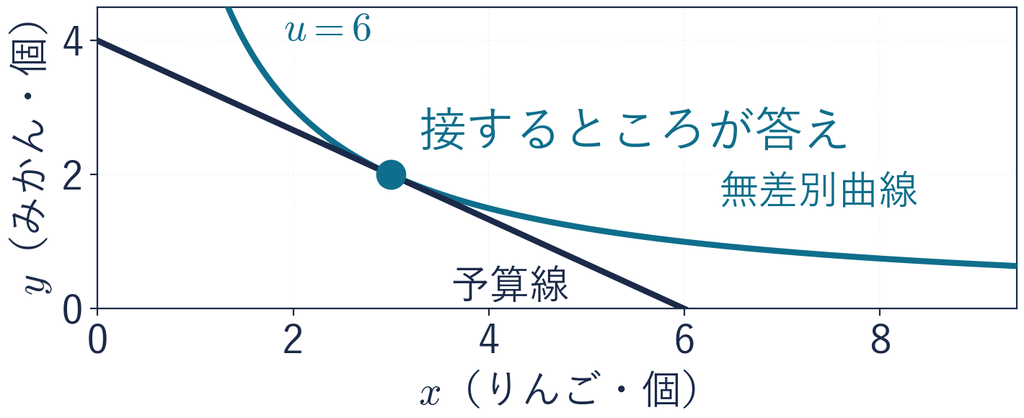

- **交換の割合**：限界代替率。$u = xy$ なら $\frac{y}{x}$
- **使い切る**：予算は $\leq$ でも、答えは使い切る線（$=$）の上
- **接する**：答えは、無差別曲線が予算線に接する点。$L = f + \lambda g$ と $4$ STEP で出す
- **割って消す**：①②に $x$ と $y$ が両方入るときは、割って $\lambda$ を消す。最小でも同じ手順
- **罰の見方**：$\lambda g$ は縛りを守らせる罰。ちょうどよい罰で同じ答え

$\lambda$ が何の数かは、あとで決着をつける  
動画の中の**演習 1-1〜4-1** を解き、配った答えで確かめる → 第10回はここまで